# Exploring the human genome (Part 3) - Chromosomes

Dr. Shirin Glander

2016-12-12

In this part I want to explore the chromosomes of the human genome. We have 23 chromose pairs, 22 autosomal pairs which contain essentially the same genes (albeit in slightly different versions, called alleles) and the gonosomes (or sex chromosomes) X and Y, plus the mitochondrial (MT) chromosome. X and Y contain different genes and in this capacity encode sex-related traits. The MT is the remaining genetic information from what initially started as a symbiosis. The majority of the mitochondrial genes were lost over time or have been incorporated into the main nuclear DNA, but a handful of genes remains to this day. MT genes are interesting because they are solely inherited via the female line as they come with the mitochondria in the fertilized egg.

I am again using the [AnnotationDbi](https://bioconductor.org/packages/release/bioc/html/AnnotationDbi.html) and [EnsDb.Hsapiens.v79](https://bioconductor.org/packages/release/data/annotation/html/EnsDb.Hsapiens.v79.html) packages. This time I want to extract the following information for each gene:

- on which chromosome it lives
- the length of the chromosome it lives on (in base pairs, bp)
- whether it is on the plus or minus strand
- and the coordinates of start and end position.

Based on start and end position of each gene I can calculate its length in base pairs (bp).

Click here for [Part 1](https://shiring.github.io/genome/2016/10/23/AnnotationDbi) and [Part 2](https://shiring.github.io/genome/2016/11/01/AnnotationDbi_part2).

```r
library(AnnotationDbi)
library(EnsDb.Hsapiens.v79)
edb_Hs <- EnsDb.Hsapiens.v79

# get all gene IDs (Ensembl gene ID)
keys_Hs <- keys(edb_Hs, keytype = "GENEID")

chromosomes_Hs <- AnnotationDbi::select(edb_Hs, keys = keys_Hs, columns = c("SEQLENGTH", "SEQNAME", "SEQSTRAND", "GENESEQSTART", "GENESEQEND"), keytype = "GENEID")

# convert chromosome and strand to factors
chromosomes_Hs$SEQNAME <- as.factor(chromosomes_Hs$SEQNAME)
chromosomes_Hs$SEQSTRAND <- as.factor(chromosomes_Hs$SEQSTRAND)

# calculate gene length
chromosomes_Hs$GENELENGTH <- chromosomes_Hs$GENESEQEND - chromosomes_Hs$GENESEQSTART

head(chromosomes_Hs)
```

```
##            GENEID SEQLENGTH SEQNAME SEQSTRAND GENESEQSTART GENESEQEND
## 1 ENSG00000000003 156040895       X        -1    100627109  100639991
## 2 ENSG00000000005 156040895       X         1    100584802  100599885
## 3 ENSG00000000419  64444167      20        -1     50934867   50958555
## 4 ENSG00000000457 248956422       1        -1    169849631  169894267
## 5 ENSG00000000460 248956422       1         1    169662007  169854080
## 6 ENSG00000000938 248956422       1        -1     27612064   27635277
##   GENELENGTH
## 1      12882
## 2      15083
## 3      23688
## 4      44636
## 5     192073
## 6      23213
```

```r
library(EnsDb.Mmusculus.v79)
edb_Mm <- EnsDb.Mmusculus.v79

# get all gene IDs (Ensembl gene ID)
keys_Mm <- keys(edb_Mm, keytype = "GENEID")

chromosomes_Mm <- AnnotationDbi::select(edb_Mm, keys = keys_Mm, columns = c("SEQLENGTH", "SEQNAME", "SEQSTRAND", "GENESEQSTART", "GENESEQEND"), keytype = "GENEID")

# convert chromosome and strand to factors
chromosomes_Mm$SEQNAME <- as.factor(chromosomes_Mm$SEQNAME)
chromosomes_Mm$SEQSTRAND <- as.factor(chromosomes_Mm$SEQSTRAND)

# calculate gene length
chromosomes_Mm$GENELENGTH <- chromosomes_Mm$GENESEQEND - chromosomes_Mm$GENESEQSTART

head(chromosomes_Mm)
```

```
##               GENEID SEQLENGTH SEQNAME SEQSTRAND GENESEQSTART GENESEQEND
## 1 ENSMUSG00000000001 160039680       3        -1    108107280  108146146
## 2 ENSMUSG00000000003 171031299       X        -1     77837901   77853623
## 3 ENSMUSG00000000028  98207768      16        -1     18780447   18811987
## 4 ENSMUSG00000000031 145441459       7        -1    142575529  142578143
## 5 ENSMUSG00000000037 171031299       X         1    161117193  161258213
## 6 ENSMUSG00000000049 122082543      11         1    108343354  108414396
##   GENELENGTH
## 1      38866
## 2      15722
## 3      31540
## 4       2614
## 5     141020
## 6      71042
```

```r
library(EnsDb.Rnorvegicus.v79)
edb_Rn <- EnsDb.Rnorvegicus.v79

# get all gene IDs (Ensembl gene ID)
keys_Rn <- keys(edb_Rn, keytype = "GENEID")

chromosomes_Rn <- AnnotationDbi::select(edb_Rn, keys = keys_Rn, columns = c("SEQLENGTH", "SEQNAME", "SEQSTRAND", "GENESEQSTART", "GENESEQEND"), keytype = "GENEID")

# convert chromosome and strand to factors
chromosomes_Rn$SEQNAME <- as.factor(chromosomes_Rn$SEQNAME)
chromosomes_Rn$SEQSTRAND <- as.factor(chromosomes_Rn$SEQSTRAND)

# calculate gene length
chromosomes_Rn$GENELENGTH <- chromosomes_Rn$GENESEQEND - chromosomes_Rn$GENESEQSTART

head(chromosomes_Rn)
```

```
##               GENEID SEQLENGTH SEQNAME SEQSTRAND GENESEQSTART GENESEQEND
## 1 ENSRNOG00000000001 285068071       2         1    249516525  250013503
## 2 ENSRNOG00000000007 183740530       3         1     63479963   63519877
## 3 ENSRNOG00000000008 183740530       3         1     89249578   89286113
## 4 ENSRNOG00000000009 183740530       3         1    111335116  111350242
## 5 ENSRNOG00000000010  72914587      19         1     31617915   31621724
## 6 ENSRNOG00000000012 183740530       3         1    153992077  153998331
##   GENELENGTH
## 1     496978
## 2      39914
## 3      36535
## 4      15126
## 5       3809
## 6       6254
```

## How many bases of each chromosome are taken up by genes?

In order to calculate the sum of gene lengths for each chromosome I am using the *aggregate()* function. We can already see that there are many more unique chromosome identifiers than the 25 regular chromosomes we had expected:

```r
gene_bases_Hs <- aggregate(chromosomes_Hs$GENELENGTH, by = list(Chromosome = chromosomes_Hs$SEQNAME), FUN = sum)
length(unique(gene_bases_Hs$Chromosome))
```

```
## [1] 319
```

This is because some of the genes have not yet been successfully mapped to a chromosome. Genes with seqnames that start with “KI” or “GL” for example, currently live on scaffolds where the chromosomal location is not yet known.

- **check what the other seqnames mean**

Here I only want to have a look at the 25 chromosomes and lump the unmapped scaffolds into one group of unknown chromosomes.

```r
gene_bases_Mm <- aggregate(chromosomes_Mm$GENELENGTH, by = list(Chromosome = chromosomes_Mm$SEQNAME), FUN = sum)
length(unique(gene_bases_Mm$Chromosome))
```

```
## [1] 61
```

```r
gene_bases_Rn <- aggregate(chromosomes_Rn$GENELENGTH, by = list(Chromosome = chromosomes_Rn$SEQNAME), FUN = sum)
length(unique(gene_bases_Rn$Chromosome))
```

```
## [1] 95
```

```r
chrom_Hs <- as.character(gene_bases_Hs[grep("^[0-9]+$|^X$|^Y$|^MT$", gene_bases_Hs$Chromosome), "Chromosome"])

gene_bases_other_Hs <- gene_bases_Hs[-which(gene_bases_Hs$Chromosome %in% chrom_Hs), ]
scaffolds_Hs <- data.frame(Chromosome = "S", x = sum(gene_bases_other_Hs[grep("^KI[0-9]+|^GL[0-9]+", gene_bases_other_Hs$Chromosome), "x"]))

library(dplyr)
gene_bases_Hs <- gene_bases_Hs[which(gene_bases_Hs$Chromosome %in% chrom_Hs), ] %>%
  rbind(scaffolds_Hs)

length(unique(gene_bases_Hs$Chromosome))
```

```
## [1] 26
```

```r
chrom_Mm <- as.character(gene_bases_Mm[grep("^[0-9]+$|^X$|^Y$|^MT$", gene_bases_Mm$Chromosome), "Chromosome"])

gene_bases_other_Mm <- gene_bases_Mm[-which(gene_bases_Mm$Chromosome %in% chrom_Mm), ]
scaffolds_Mm <- data.frame(Chromosome = "S", x = sum(gene_bases_other_Mm[grep("^JH[0-9]+|^GL[0-9]+", gene_bases_other_Mm$Chromosome), "x"]))

library(dplyr)
gene_bases_Mm <- gene_bases_Mm[which(gene_bases_Mm$Chromosome %in% chrom_Mm), ] %>%
  rbind(scaffolds_Mm)

length(unique(gene_bases_Mm$Chromosome))
```

```
## [1] 23
```

```r
chrom_Rn <- as.character(gene_bases_Rn[grep("^[0-9]+$|^X$|^Y$|^MT$", gene_bases_Rn$Chromosome), "Chromosome"])

gene_bases_other_Rn <- gene_bases_Rn[-which(gene_bases_Rn$Chromosome %in% chrom_Rn), ]
scaffolds_Rn <- data.frame(Chromosome = "S", x = sum(gene_bases_other_Rn[grep("^JH[0-9]+|^AABR[0-9]+", gene_bases_other_Rn$Chromosome), "x"]))

library(dplyr)
gene_bases_Rn <- gene_bases_Rn[which(gene_bases_Rn$Chromosome %in% chrom_Rn), ] %>%
  rbind(scaffolds_Rn)

length(unique(gene_bases_Rn$Chromosome))
```

```
## [1] 23
```

## How many genes are on each chromosome?

To count the number of genes per chromosome I am using the *table()* function.

```r
chromosomes_num_table_Hs <- as.data.frame(table(chromosomes_Hs$SEQNAME))

chromosomes_num_table_other_Hs <- chromosomes_num_table_Hs[-which(chromosomes_num_table_Hs$Var1 %in% chrom_Hs), ]
scaffolds_Hs <- data.frame(Var1 = "S", Freq = sum(chromosomes_num_table_other_Hs[grep("^KI[0-9]+|^GL[0-9]+", chromosomes_num_table_other_Hs$Var1), "Freq"]))

chromosomes_num_table_Hs <- chromosomes_num_table_Hs[which(chromosomes_num_table_Hs$Var1 %in% chrom_Hs), ] %>%
  rbind(scaffolds_Hs)
```

```r
chromosomes_num_table_Mm <- as.data.frame(table(chromosomes_Mm$SEQNAME))

chromosomes_num_table_other_Mm <- chromosomes_num_table_Mm[-which(chromosomes_num_table_Mm$Var1 %in% chrom_Mm), ]
scaffolds_Mm <- data.frame(Var1 = "S", Freq = sum(chromosomes_num_table_other_Mm[grep("^JH[0-9]+|^GL[0-9]+", chromosomes_num_table_other_Mm$Var1), "Freq"]))

chromosomes_num_table_Mm <- chromosomes_num_table_Mm[which(chromosomes_num_table_Mm$Var1 %in% chrom_Mm), ] %>%
  rbind(scaffolds_Mm)
```

```r
chromosomes_num_table_Rn <- as.data.frame(table(chromosomes_Rn$SEQNAME))

chromosomes_num_table_other_Rn <- chromosomes_num_table_Rn[-which(chromosomes_num_table_Rn$Var1 %in% chrom_Rn), ]
scaffolds_Rn <- data.frame(Var1 = "S", Freq = sum(chromosomes_num_table_other_Rn[grep("^JH[0-9]+|^AABR[0-9]+", chromosomes_num_table_other_Rn$Var1), "Freq"]))

chromosomes_num_table_Rn <- chromosomes_num_table_Rn[which(chromosomes_num_table_Rn$Var1 %in% chrom_Rn), ] %>%
  rbind(scaffolds_Rn)
```

## How long are the chromosomes?

The information about chromosome length in base pairs (bp) is given in the column “SEQLENGTH”:

```r
chrom_length_Hs <- chromosomes_Hs[!duplicated(chromosomes_Hs$SEQNAME), c(3,2)] #SEQNAME & SEQLENGTH

chrom_length_other_Hs <- chrom_length_Hs[-which(chrom_length_Hs$SEQNAME %in% chrom_Hs), ]
scaffolds_Hs <- data.frame(SEQNAME = "S", SEQLENGTH = sum(chrom_length_other_Hs[grep("^KI[0-9]+|^GL[0-9]+", chrom_length_other_Hs$SEQNAME), "SEQLENGTH"]))

chrom_length_Hs <- chrom_length_Hs[which(chrom_length_Hs$SEQNAME %in% chrom_Hs), ] %>%
  rbind(scaffolds_Hs)
```

```r
chrom_length_Mm <- chromosomes_Mm[!duplicated(chromosomes_Mm$SEQNAME), c(3,2)] #SEQNAME & SEQLENGTH

chrom_length_other_Mm <- chrom_length_Mm[-which(chrom_length_Mm$SEQNAME %in% chrom_Mm), ]
scaffolds_Mm <- data.frame(SEQNAME = "S", SEQLENGTH = sum(chrom_length_other_Mm[grep("^JH[0-9]+|^GL[0-9]+", chrom_length_other_Mm$SEQNAME), "SEQLENGTH"]))

chrom_length_Mm <- chrom_length_Mm[which(chrom_length_Mm$SEQNAME %in% chrom_Mm), ] %>%
  rbind(scaffolds_Mm)
```

```r
chrom_length_Rn <- chromosomes_Rn[!duplicated(chromosomes_Rn$SEQNAME), c(3,2)] #SEQNAME & SEQLENGTH

chrom_length_other_Rn <- chrom_length_Rn[-which(chrom_length_Rn$SEQNAME %in% chrom_Rn), ]
scaffolds_Rn <- data.frame(SEQNAME = "S", SEQLENGTH = sum(chrom_length_other_Rn[grep("^JH[0-9]+|^AABR[0-9]+", chrom_length_other_Rn$SEQNAME), "SEQLENGTH"]))

chrom_length_Rn <- chrom_length_Rn[which(chrom_length_Rn$SEQNAME %in% chrom_Rn), ] %>%
  rbind(scaffolds_Rn)
```

Now, I can combine the information about

- how long each chromosome is,
- how much of it is made up of genes and
- how many genes there are it

into a single dataframe.

```r
chromosomes_table_Hs <- left_join(chrom_length_Hs, chromosomes_num_table_Hs, by = c("SEQNAME" = "Var1")) %>%
  left_join(gene_bases_Hs, by = c("SEQNAME" = "Chromosome"))

colnames(chromosomes_table_Hs) <- c("Chromosome", "Chr_length", "No_genes", "Gene_lengths_sum")
```

```r
chromosomes_table_Mm <- left_join(chrom_length_Mm, chromosomes_num_table_Mm, by = c("SEQNAME" = "Var1")) %>%
  left_join(gene_bases_Mm, by = c("SEQNAME" = "Chromosome"))

colnames(chromosomes_table_Mm) <- c("Chromosome", "Chr_length", "No_genes", "Gene_lengtMm_sum")
```

```r
chromosomes_table_Rn <- left_join(chrom_length_Rn, chromosomes_num_table_Rn, by = c("SEQNAME" = "Var1")) %>%
  left_join(gene_bases_Rn, by = c("SEQNAME" = "Chromosome"))

colnames(chromosomes_table_Rn) <- c("Chromosome", "Chr_length", "No_genes", "Gene_lengtRn_sum")
```

```r
chromosomes_table_Hs$No_genes_by_Chr_length <- chromosomes_table_Hs$No_genes/chromosomes_table_Hs$Chr_length
chromosomes_table_Hs$Percent_of_Chr_covered_by_genes <- round(chromosomes_table_Hs$Gene_lengths_sum/chromosomes_table_Hs$Chr_length*100, digits = 2)
```

```r
chromosomes_table_Mm$No_genes_by_Chr_length <- chromosomes_table_Mm$No_genes/chromosomes_table_Mm$Chr_length
chromosomes_table_Mm$Percent_of_Chr_covered_by_genes <- round(chromosomes_table_Mm$Gene_lengtMm_sum/chromosomes_table_Mm$Chr_length*100, digits = 2)
```

```r
chromosomes_table_Rn$No_genes_by_Chr_length <- chromosomes_table_Rn$No_genes/chromosomes_table_Rn$Chr_length
chromosomes_table_Rn$Percent_of_Chr_covered_by_genes <- round(chromosomes_table_Rn$Gene_lengtRn_sum/chromosomes_table_Rn$Chr_length*100, digits = 2)
```

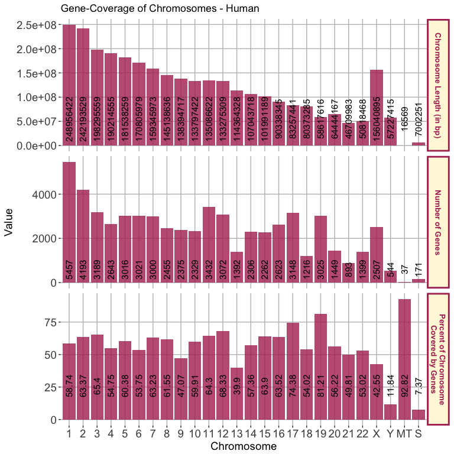

```r
library(reshape2)
chromosomes_table_m_Hs <- melt(chromosomes_table_Hs[, c(1,2,3,6)])

f_Hs = c("1", "2", "3", "4", "5", "6", "7", "8", "9", "10", "11", "12", "13", "14", "15", "16", "17", "18", "19", "20", "21", "22", "X", "Y", "MT", "S")
chromosomes_table_m_Hs <- within(chromosomes_table_m_Hs, Chromosome <- factor(Chromosome, levels = f_Hs))

labels <- c(No_genes = "Number of Genes",
            Chr_length = "Chromosome Length (in bp)",
            Percent_of_Chr_covered_by_genes = "Percent of Chromosome\nCovered by Genes")

library(ggplot2)
p <- ggplot(data = chromosomes_table_m_Hs, aes(x = Chromosome, y = value)) +
  geom_bar(stat = "identity", fill = "maroon", alpha = 0.8) +
  theme(
    axis.text = element_text(size = 14),
    axis.title = element_text(size = 14),
    panel.grid.major = element_line(colour = "grey"),
    panel.grid.minor = element_blank(),
    panel.background = element_rect(fill = "white"),
    strip.background = element_rect(fill = "cornsilk", color = "maroon", size = 2),
    strip.text = element_text(face = "bold", size = 10, colour = "maroon")
  ) +
  labs(
    title = "Gene-Coverage of Chromosomes - Human",
    x = "Chromosome",
    y = "Value") +
  facet_grid(variable ~ ., scales = "free", labeller = labeller(variable = labels))

ann_text_Hs <- data.frame(x = chromosomes_table_m_Hs$Chromosome,
                       y = c(rep(55000000, 26), rep(600, 26), rep(26, 26)),
                       lab = as.character(chromosomes_table_m_Hs$value),
                       variable = chromosomes_table_m_Hs$variable)

p + geom_text(data = ann_text_Hs, aes(x, y, label = lab, group = variable), size = 4, angle = 90)
```

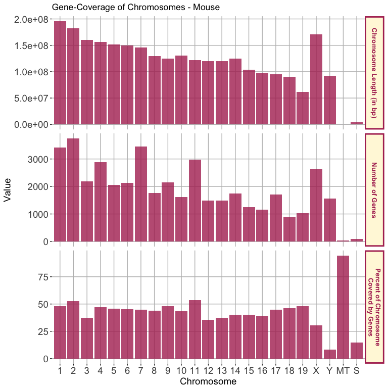

```r
chromosomes_table_m_Mm <- melt(chromosomes_table_Mm[, c(1,2,3,6)])

f_Mm = c("1", "2", "3", "4", "5", "6", "7", "8", "9", "10", "11", "12", "13", "14", "15", "16", "17", "18", "19", "X", "Y", "MT", "S")
chromosomes_table_m_Mm <- within(chromosomes_table_m_Mm, Chromosome <- factor(Chromosome, levels = f_Mm))

labels <- c(No_genes = "Number of Genes",
            Chr_length = "Chromosome Length (in bp)",
            Percent_of_Chr_covered_by_genes = "Percent of Chromosome\nCovered by Genes")

p <- ggplot(data = chromosomes_table_m_Mm, aes(x = Chromosome, y = value)) +
  geom_bar(stat = "identity", fill = "maroon", alpha = 0.8) +
  theme(
    axis.text = element_text(size = 14),
    axis.title = element_text(size = 14),
    panel.grid.major = element_line(colour = "grey"),
    panel.grid.minor = element_blank(),
    panel.background = element_rect(fill = "white"),
    strip.background = element_rect(fill = "cornsilk", color = "maroon", size = 2),
    strip.text = element_text(face = "bold", size = 10, colour = "maroon")
  ) +
  labs(
    title = "Gene-Coverage of Chromosomes - Mouse",
    x = "Chromosome",
    y = "Value") +
  facet_grid(variable ~ ., scales = "free", labeller = labeller(variable = labels))

#ann_text_Mm <- data.frame(x = chromosomes_table_m_Mm$Chromosome,
#                          y = c(rep(55000000, 23), rep(600, 23), rep(26, 23)),
#                          lab = as.character(chromosomes_table_m_Mm$value),
#                          variable = chromosomes_table_Mm$variable)

p #+ geom_text(data = ann_text_Mm, aes(x, y, label = lab, group = variable), size = 4, angle = 90)
```

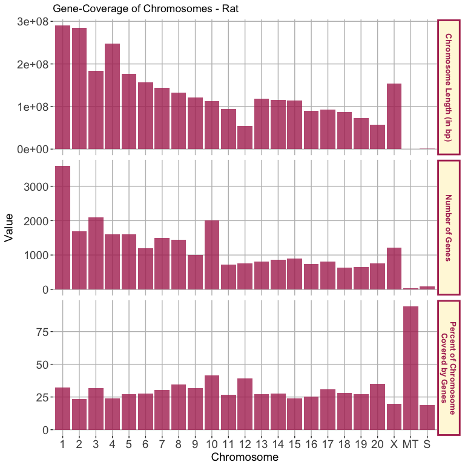

```r
chromosomes_table_m_Rn <- melt(chromosomes_table_Rn[, c(1,2,3,6)])

f_Rn = c("1", "2", "3", "4", "5", "6", "7", "8", "9", "10", "11", "12", "13", "14", "15", "16", "17", "18", "19", "20", "X", "MT", "S")
chromosomes_table_m_Rn <- within(chromosomes_table_m_Rn, Chromosome <- factor(Chromosome, levels = f_Rn))

labels <- c(No_genes = "Number of Genes",
            Chr_length = "Chromosome Length (in bp)",
            Percent_of_Chr_covered_by_genes = "Percent of Chromosome\nCovered by Genes")

p <- ggplot(data = chromosomes_table_m_Rn, aes(x = Chromosome, y = value)) +
  geom_bar(stat = "identity", fill = "maroon", alpha = 0.8) +
  theme(
    axis.text = element_text(size = 14),
    axis.title = element_text(size = 14),
    panel.grid.major = element_line(colour = "grey"),
    panel.grid.minor = element_blank(),
    panel.background = element_rect(fill = "white"),
    strip.background = element_rect(fill = "cornsilk", color = "maroon", size = 2),
    strip.text = element_text(face = "bold", size = 10, colour = "maroon")
  ) +
  labs(
    title = "Gene-Coverage of Chromosomes - Rat",
    x = "Chromosome",
    y = "Value") +
  facet_grid(variable ~ ., scales = "free", labeller = labeller(variable = labels))

#ann_text_Rn <- data.frame(x = chromosomes_table_m_Rn$Chromosome,
#                          y = c(rep(55000000, 23), rep(600, 23), rep(26, 23)),
#                          lab = as.character(chromosomes_table_m_Rn$value),
#                          variable = chromosomes_table_Rn$variable)

p #+ geom_text(data = ann_text_Rn, aes(x, y, label = lab, group = variable), size = 4, angle = 90)
```